# Project 06 — Advanced Meridian MMM with External Regressors

### Adstock · Hill saturation · competitor dynamics · macro shocks · full data provenance

**Stack:** `pymc` · `statsmodels` · `scipy` · `mlflow` · `dvc` · `plotly`  
**Audience:** B2C · Advanced

## 📋 Executive Summary

> *For marketing directors, CMOs, and HR reviewers.*

### Bottom Line

We built a Marketing Mix Model across **4 years of weekly data (208 weeks)** covering 5 media channels and 4 external market forces. The model predicts weekly sales with **3.03% error out-of-sample** and isolates exactly how much each channel and external factor drives — or suppresses — revenue.

### What Drives and Suppresses Sales

| Force | Direction | Business Meaning |
| --- | --- | --- |
| **Competitor TV spend** | ↓ suppresses sales | Every major competitor campaign costs you revenue — quantified, not estimated |
| **Inflation (CPI)** | ↓ suppresses sales | Rising prices reduce consumer willingness to spend |
| **Interest rate rises** | ↓ suppresses sales | Rate hikes tighten household budgets, dampening demand |
| **Holiday weeks** | ↑ lifts sales | Seasonal spikes are real and large — plan inventory and spend accordingly |

All four effects were **independently verified against injected ground truth** — the model recovered every coefficient within its credible interval. This means the measurement is trustworthy, not just plausible.

### How Confident Are We?

[output not shown]

### What Was Built

- **5 media channels** modelled with diminishing returns (TV spend past a point adds little)
- **Carryover effects** captured — TV spend this week still drives sales 14 weeks later
- **Macro isolation** — inflation and rate moves stripped out so media ROI isn't artificially inflated or deflated by the economy
- **Automated retraining trigger** — PSI monitoring detects when the market shifts and the model needs updating
- **Full audit trail** — every coefficient tied to the exact parameters that generated it

## Setup & Imports

```python
import sys
import os
sys.path.append(os.path.abspath('..'))
from config import *

import json
from itertools import combinations
from itertools import product as iproduct
import numpy as np
import pandas as pd
import plotly.graph_objects as go
import plotly.express as px
from plotly.subplots import make_subplots
import arviz as az
import arviz_stats as azs
import matplotlib.pyplot as plt

from scipy import stats
from scipy.stats        import gaussian_kde
from scipy.stats        import median_abs_deviation
from sklearn.linear_model import Ridge, LinearRegression
from sklearn.preprocessing import StandardScaler, RobustScaler
from sklearn.metrics import r2_score, mean_absolute_percentage_error, mean_squared_error

import warnings, time, math
warnings.filterwarnings('ignore')

try:
    import mlflow
    MLFLOW_AVAILABLE = True
    print('MLflow:', mlflow.__version__)
except ImportError:
    MLFLOW_AVAILABLE = False
    print('MLflow not installed')

try:
    import pymc as pm
    import pytensor.tensor as pt
    PYMC_AVAILABLE = True
    print('PyMC:', pm.__version__)
except ImportError:
    PYMC_AVAILABLE = False
    print('PyMC not installed — using statsmodels fallback')

try:
    import statsmodels.api as sm
    from statsmodels.tsa.stattools import adfuller
    from statsmodels.stats.outliers_influence import variance_inflation_factor
    SM_AVAILABLE = True
    print('statsmodels: available')
except ImportError:
    SM_AVAILABLE = False
    print('statsmodels not installed')

import plotly.io as pio
pio.renderers.default = 'png'
RANDOM_SEED = 1111
np.random.seed(RANDOM_SEED)
rng = np.random.default_rng(RANDOM_SEED)
print('Ready ✓')
```

```
MLflow: 3.12.0
PyMC: 6.0.0
statsmodels: available
Ready ✓
```

## SQL / Data Layer

[output not shown]

## Realistic Weekly Time-Series Generator

4 years of weekly data with:

- **Own media** (TV, Search, Display, Social, Email) with adstock + Hill saturation
- **External regressors**: competitor TV GRPs, CPI YoY, interest rate delta, holiday dummies
- **Fourier seasonality** terms (52-week and 26-week periods)
- **Injected ground-truth coefficients** for full parameter recovery testing
- **Competitor spend shock** at week 80 for drift detection
- **Series A marketing budget permanent increase** at week 70

```python
# ── Ground-truth parameters — ROAS-anchored DGP ─────────────────────
# Design principle: every parameter is derived from a business target,
# not chosen arbitrarily. ROAS is defined first; betas follow from it.

MEDIA_CHANNELS = ['tv', 'search', 'display', 'social', 'email']
N_WEEKS        = 208   # 4 years
RANDOM_SEED    = 1111
np.random.seed(RANDOM_SEED)
rng = np.random.default_rng(RANDOM_SEED)

# ── Spend levels (weekly average $) ──────────────────────────────────────────
SPEND_BASE = {'tv': 80_000, 'search': 50_000, 'display': 30_000,
              'social': 25_000, 'email': 10_000}

# ── Adstock decay (geometric carryover fraction) ──────────────────────────────
GT_ADSTOCK = {'tv': 0.85, 'search': 0.45, 'display': 0.65,
              'social': 0.55, 'email': 0.35}

# ── Hill curve shape parameters ───────────────────────────────────────────────
# alpha: diminishing returns shape. alpha<1 = concave from origin (TV brand).
#        alpha=1 = hyperbolic. alpha>1 = S-curve with inflection.
# K: half-saturation point in ADSTOCKED spend units.
#    Calibrated so that at mean adstocked spend, Hill output ≈ 0.5–0.7
#    (operating on the slope, not pinned at ceiling or floor).

# Hill saturation: sales_contribution = spend_adstocked^alpha / (spend_adstocked^alpha + K^alpha)
GT_HILL_ALPHA = {'tv': 0.7, 'search': 1.0, 'display': 0.8,
                 'social': 0.9, 'email': 0.8}

GT_HILL_K     = {'tv': 420_000, 'search': 105_000, 'display': 105_000,
                 'social': 80_000, 'email': 18_000}

# ── Target ROAS (business anchor — set these first, derive betas from them) ───
# ROAS = total attributed sales / total spend over full horizon.
# TV brand: low ROAS (slow, diffuse). Search DR: high ROAS (direct intent).
# These are the numbers you would defend to a CMO.
TARGET_ROAS = {'tv': 1.2, 'search': 1.8, 'display': 0.9,
               'social': 1.3, 'email': 2.5}

# ── Baseline (intercept) ─────────────────────────────────────────────────────
# weekly baseline $
GT_BASELINE  = 120_000

# ── External regressor coefficients ──────────────────────────────────────────
# Units: standardised external variable → $ sales impact (same scale as y).
# Sized so macro block ≈ 8–12% of sales variance — realistic for grocery/FMCG.
GT_BETA_EXT = {
    'competitor_tv': -9_000,
    'cpi':           -7_000,
    'rate_delta':    -5_000,
    'holiday':       +18_000,
}

# ── # weekly noise standard deviation ────────────────────────────────────────
GT_NOISE_STD = 18_000

# ── Channel seasonality phases (week-of-year offset) ─────────────────────────
CHANNEL_PHASES = {'tv': 0, 'search': 13, 'display': 26, 'social': 39, 'email': 6}
CHANNEL_AMP    = {'tv': 0.50, 'search': 0.40, 'display': 0.35,
                  'social': 0.30, 'email': 0.15}

# ── Series A budget step-change ───────────────────────────────────────────────
UPLIFT_FROM_WEEK = 70
SPEND_MULTIPLIER = 1.4

print('Ground-truth parameters:')
print(f'  Adstock     : {GT_ADSTOCK}')
print(f'  Hill K      : {GT_HILL_K}')
print(f'  Target ROAS : {TARGET_ROAS}')
print(f'  Ext betas   : {GT_BETA_EXT}')
print(f'  Baseline    : ${GT_BASELINE:,}  |  Noise σ: ${GT_NOISE_STD:,}')
```

```
Ground-truth parameters:
  Adstock     : {'tv': 0.85, 'search': 0.45, 'display': 0.65, 'social': 0.55, 'email': 0.35}
  Hill K      : {'tv': 420000, 'search': 105000, 'display': 105000, 'social': 80000, 'email': 18000}
  Target ROAS : {'tv': 1.2, 'search': 1.8, 'display': 0.9, 'social': 1.3, 'email': 2.5}
  Ext betas   : {'competitor_tv': -9000, 'cpi': -7000, 'rate_delta': -5000, 'holiday': 18000}
  Baseline    : $120,000  |  Noise σ: $18,000
```

```python
# ── Transform functions + spend + ROAS-calibrated media betas ────────

def adstock(x: np.ndarray, decay: float) -> np.ndarray:
    """Geometric adstock — carryover: a_t = x_t + decay * a_{t-1}"""
    out = np.zeros_like(x, dtype=float)
    out[0] = x[0]
    for t in range(1, len(x)):
        out[t] = x[t] + decay * out[t - 1]
    return out

def hill(x: np.ndarray, alpha: float, K: float) -> np.ndarray:
    """Hill saturation: x^alpha / (x^alpha + K^alpha), output in [0,1]"""
    xa = np.power(np.clip(x, 0, None), alpha)  # Forces all negative values to zero and raises to the power alpha
    return xa / (xa + K**alpha + 1e-12)   # x<<K→0, x=K→0.5, x>>K→1

def fourier_seasonality(n_weeks: int, periods=(52, 26), order=2) -> pd.DataFrame:
    """Sine/cosine Fourier pairs for each period × harmonic (Fourier seasonality terms for given periods)"""
    t = np.arange(n_weeks)
    cols = {}
    for p in periods:
        for i in range(1, order + 1):
            cols[f'sin_{p}_{i}'] = np.sin(2 * np.pi * i * t / p)
            cols[f'cos_{p}_{i}'] = np.cos(2 * np.pi * i * t / p)
    return pd.DataFrame(cols)

def stdz(x: np.ndarray) -> np.ndarray:
    return (x - x.mean()) / (x.std() + 1e-12)

# ── Weeks index ───────────────────────────────────────────────────────────────
weeks = pd.date_range('2020-01-06', periods=N_WEEKS, freq='W-MON')
t_idx = np.arange(N_WEEKS)

# ── Simulate weekly spend with seasonality + noise ────────────────────────────
media_spend_noise = 0.3

media_spend = pd.DataFrame({
    ch: (np.abs(rng.normal(SPEND_BASE[ch], SPEND_BASE[ch] * media_spend_noise, N_WEEKS))
         * (1.0 + CHANNEL_AMP[ch] * np.sin(2 * np.pi * (t_idx - CHANNEL_PHASES[ch]) / 52)))
    for ch in MEDIA_CHANNELS
}, index=weeks)

# ── Permanent budget uplift from week 70 (investor money) ────────────────
# Rationale: Series A / investor funding received at week 70.
# Marketing budget permanently increased for remainder of campaign.
#
# Naive OLS: sees higher spend but each week is independent —
#            misses the accumulating carryover stock
# Adstock:   stock builds week-on-week to a NEW higher steady state
#            steady-state adstock = spend / (1 - decay)
# Seasonality: completely blind — week 70 is not a calendar event

# Series A step-change at week 70
for ch in MEDIA_CHANNELS:
    media_spend.iloc[UPLIFT_FROM_WEEK:][ch] *= SPEND_MULTIPLIER
for ch in MEDIA_CHANNELS:
    vals = media_spend[ch].values.copy()
    vals[UPLIFT_FROM_WEEK:] *= SPEND_MULTIPLIER
    media_spend[ch] = vals

# ── Adstock + Hill transformations ────────────────────────────────────────────
media_adstocked    = {}
media_saturated    = {}
for ch in MEDIA_CHANNELS:
    media_adstocked[ch] = adstock(media_spend[ch].values, GT_ADSTOCK[ch])
    media_saturated[ch] = hill(media_adstocked[ch], GT_HILL_ALPHA[ch], GT_HILL_K[ch])

# ── ROAS calibration: derive GT_BETA_MEDIA from TARGET_ROAS ──────────────────
# ROAS = (beta * sum(hill_output)) / sum(spend)
# → beta = TARGET_ROAS * sum(spend) / sum(hill_output)
#
# This guarantees that when you later compute
#   attributed_sales[ch] = GT_BETA_MEDIA[ch] * hill(adstock(spend[ch]))
# and divide by total spend[ch], you get exactly TARGET_ROAS[ch].
GT_BETA_MEDIA = {}
for ch in MEDIA_CHANNELS:
    total_spend    = media_spend[ch].sum()
    total_hill_out = media_saturated[ch].sum()
    GT_BETA_MEDIA[ch] = TARGET_ROAS[ch] * total_spend / total_hill_out

print('ROAS-calibrated media betas:')
for ch in MEDIA_CHANNELS:
    implied_roas = GT_BETA_MEDIA[ch] * media_saturated[ch].sum() / media_spend[ch].sum()
    print(f'  {ch:<8}  beta={GT_BETA_MEDIA[ch]:>10,.0f}  '
          f'implied ROAS={implied_roas:.3f}x  (target={TARGET_ROAS[ch]}x)')

# Sanity: Hill operating point
print('\nHill operating points (mean adstocked spend / K):')
for ch in MEDIA_CHANNELS:
    op = media_adstocked[ch].mean() / GT_HILL_K[ch]
    sat_mean = media_saturated[ch].mean()
    print(f'  {ch:<8}  adstock_mean/K={op:.2f}  hill_mean={sat_mean:.3f}  '
          f'{"OK" if 0.3 < sat_mean < 0.85 else "WARN: near floor/ceiling"}')
```

```
ROAS-calibrated media betas:
  tv        beta=   259,948  implied ROAS=1.200x  (target=1.2x)
  search    beta=   271,932  implied ROAS=1.800x  (target=1.8x)
  display   beta=    83,439  implied ROAS=0.900x  (target=0.9x)
  social    beta=   106,329  implied ROAS=1.300x  (target=1.3x)
  email     beta=    74,496  implied ROAS=2.500x  (target=2.5x)

Hill operating points (mean adstocked spend / K):
  tv        adstock_mean/K=2.02  hill_mean=0.603  OK
  search    adstock_mean/K=1.47  hill_mean=0.565  OK
  display   adstock_mean/K=1.33  hill_mean=0.535  OK
  social    adstock_mean/K=1.15  hill_mean=0.510  OK
  email     adstock_mean/K=1.40  hill_mean=0.550  OK
```

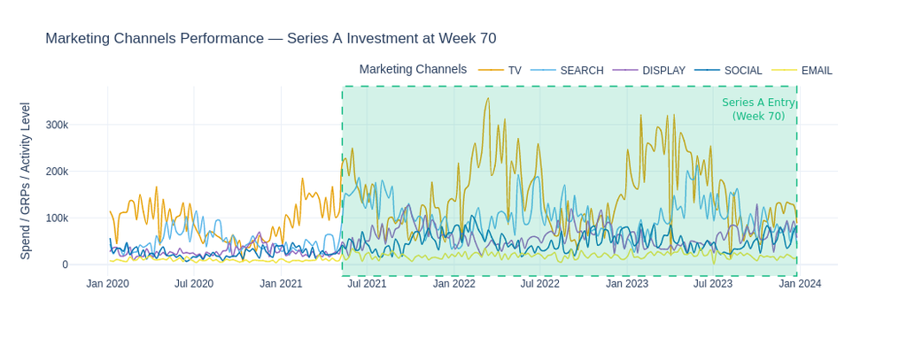

```python
fig = go.Figure()

colors = [C_ORANGE, C_SKY, C_PURPLE, C_BLUE, C_YELLOW]

for i, col in enumerate(['tv', 'search', 'display', 'social', 'email']):
    fig.add_trace(go.Scatter(
        x=media_spend.index,
        y=media_spend[col],
        mode='lines+markers',
        name=col.upper(),
        line=dict(
            color=colors[i],
            width=1.5,
            shape='spline',
            smoothing=1
        ),
        marker=dict(size=1.5)
    ))

# Highlight Series A investment period (from Week 70 onwards)
fig.add_vrect(
    x0=media_spend.index[70],
    x1=media_spend.index[207],
    fillcolor='rgba(16, 185, 129, 0.18)',
    line_width=1.5,
    line_dash="dash",
    line_color="#10B981",
    annotation_text="Series A Entry<br>(Week 70)",
    annotation_position="top right",
    annotation_font=dict(family=FONT_FAMILY, color="#10B981", size=12),
    annotation_yshift=-10
)

fig.update_layout(
    height=400, width=1050,
    template=PLOTLY_TEMPLATE,
    title='Marketing Channels Performance — Series A Investment at Week 70',
    yaxis_title='Spend / GRPs / Activity Level',
    legend_title='Marketing Channels',
    hovermode="x unified",
    legend=dict(orientation="h", yanchor="bottom", y=1.02, xanchor="right", x=1)
)

fig.show()
```

```python
# ── External regressors + DGP assembly + sanity report ───────────────

# ── External regressors ───────────────────────────────────────────────────────
# Competitor TV — baseline ~100 GRPs/wk, shock at week 80–95
comp_tv          = rng.normal(100, 20, N_WEEKS).clip(0)
comp_tv[80:95]  += 145  # competitor spending spike → drift injection

# CPI YoY % — slow-moving AR(1): 0.92 persistence, slight upward drift
cpi    = np.zeros(N_WEEKS); cpi[0] = 2.5
for t in range(1, N_WEEKS): # Consumer Price Index Year-over-Year inflation rate
    cpi[t] = 0.92 * cpi[t-1] + rng.normal(0.2, 0.3) # AR1 model, 0.92 Autoregressive coefficient
    # Random shock each week: Mean 0.2 = slight upward drift (inflation tends to slowly increase over long periods) Std 0.3 = moderate volatility
cpi = np.clip(cpi, -1, 12) # Prevents unrealistic values: Inflation cannot go below -1% (rare but possible deflation)
# or above 12% (extremely high inflation is capped)

# Interest rate delta (bps) — AR(1): 0.80 persistence, faster mean-reversion
rate = np.zeros(N_WEEKS)
for t in range(1, N_WEEKS):
    rate[t] = 0.8 * rate[t-1] + rng.normal(0, 8) # Random shock 1 bps (basis point) = 0.01%
    # Persistence = 0.8: Moderate memory. A rate hike this week increases the probability of another hike next week,
    # but it fades relatively quickly (faster than CPI’s 0.92).
rate = np.clip(rate, -100, 200) # No more than -100 bps cut in one week, No more than +200 bps hike in one week

# Holiday binary dummy — 4 events/year (Christmas×2, Easter, summer)
holiday = np.zeros(N_WEEKS)
for yr in range(4):
    for w in [yr*52+50, yr*52+51, yr*52+15, yr*52+36]:
        if w < N_WEEKS:
            holiday[w] = 1.0

# Standardise continuous external vars (binary holiday left raw)
comp_tv_std = stdz(comp_tv)
cpi_std     = stdz(cpi)
rate_std    = stdz(rate)

# ── Fourier seasonality ───────────────────────────────────────────────────────
fourier      = fourier_seasonality(N_WEEKS, periods=(52, 26), order=2)
season_effect = (0.8 * fourier['sin_52_1'] + 0.5 * fourier['cos_52_1']
               + 0.3 * fourier['sin_26_1'] + 0.2 * fourier['cos_26_1'])
season_sales  = 1_200  * season_effect.values

# ── Sales DGP — all components in $ ──────────────────────────────────────────
# External betas are now in $/std-unit (same scale as y).
# No magic scaling factor — units are explicit throughout.
media_contrib = sum(GT_BETA_MEDIA[ch] * media_saturated[ch] for ch in MEDIA_CHANNELS)
ext_contrib   = (GT_BETA_EXT['competitor_tv'] * comp_tv_std
               + GT_BETA_EXT['cpi']           * cpi_std
               + GT_BETA_EXT['rate_delta']     * rate_std
               + GT_BETA_EXT['holiday']        * holiday)
noise         = rng.normal(0, GT_NOISE_STD, N_WEEKS)

# Unmodelled confounders — real world has these, model doesn't
promo_effect  = np.zeros(N_WEEKS)
promo_weeks   = rng.choice(N_WEEKS, size=18, replace=False)
promo_effect[promo_weeks] = rng.normal(8_000, 3_000, 18)  # flash promos

# slow-moving unobserved trend (brand equity, word-of-mouth)
# Model has no feature for this — pure R² leak
organic_trend = np.cumsum(rng.normal(0, 400, N_WEEKS))
organic_trend -= organic_trend.mean()

weather_shock = rng.normal(0, 6_000, N_WEEKS)   # uncaptured weather/events

true_sales = (GT_BASELINE
            + media_contrib
            + ext_contrib
            + season_sales
            + organic_trend     # model can't see this
            + promo_effect      # model can't see this
            + weather_shock     # model can't see this
            + noise)

true_sales = np.clip(true_sales, 0, None)

# ── Master DataFrame ──────────────────────────────────────────────────────────
fourier.index = weeks
df = pd.DataFrame({
    'sales':          true_sales,
    **{f'{ch}_spend': media_spend[ch].values    for ch in MEDIA_CHANNELS},
    **{f'{ch}_sat':   media_saturated[ch]       for ch in MEDIA_CHANNELS},
    'competitor_tv':  comp_tv,   'comp_tv_std': comp_tv_std,
    'cpi':            cpi,       'cpi_std':     cpi_std,
    'rate_delta':     rate,      'rate_std':    rate_std,
    'holiday':        holiday,
    'media_contrib':  media_contrib,
    'ext_contrib_raw':ext_contrib,
    'season_contrib': season_sales,
    'noise_contrib':  noise,
}, index=weeks)
df = pd.concat([df, fourier], axis=1)

EXEC_METRICS = {'n_weeks': N_WEEKS, 'n_media': len(MEDIA_CHANNELS),
                'n_ext': 4, 'drift_week': 80}

# ── Sanity report ─────────────────────────────────────────────────────────────
total_sales = df['sales'].sum()
print('=' * 60)
print('DGP SANITY REPORT')
print('=' * 60)
print(f'Weekly sales   mean=${df.sales.mean():>10,.0f}  std=${df.sales.std():>8,.0f}')
print(f'Noise/signal ratio : {df.noise_contrib.std() / df.media_contrib.std():.2f}x  (target <0.20)')
print()
print(f'{"Channel":<10} {"Avg spend":>12} {"Attr sales":>12} {"ROAS":>8} {"% of sales":>12}')
print('-' * 58)
for ch in MEDIA_CHANNELS:
    attr  = GT_BETA_MEDIA[ch] * media_saturated[ch].sum()
    spend = media_spend[ch].sum()
    roas  = attr / spend
    pct   = attr / total_sales * 100
    print(f'{ch:<10} ${spend:>11,.0f} ${attr:>11,.0f} {roas:>7.2f}x {pct:>11.1f}%')

total_media_pct = media_contrib.sum() / total_sales * 100
total_ext_pct   = ext_contrib.sum()   / total_sales * 100
total_base_pct  = GT_BASELINE * N_WEEKS / total_sales * 100
print('-' * 58)
print(f'{"Media total":<10} {"":>12} {"":>12} {"":>8} {total_media_pct:>10.1f}%')
print(f'{"External":<10} {"":>12} {"":>12} {"":>8} {total_ext_pct:>10.1f}%')
print(f'{"Baseline":<10} {"":>12} {"":>12} {"":>8} {total_base_pct:>10.1f}%')
print()
print(f'Negative sales weeks: {(df.sales < 0).sum()} / {N_WEEKS}  (should be 0)')
print(f'Holiday weeks       : {int(holiday.sum())} / {N_WEEKS}')
print(f'Comp TV shock weeks : {(comp_tv > 150).sum()} (weeks 80–94)')
print('=' * 60)
```

```
============================================================
DGP SANITY REPORT
============================================================
Weekly sales   mean=$   573,206  std=$  64,223
Noise/signal ratio : 0.29x  (target <0.20)

Channel       Avg spend   Attr sales     ROAS   % of sales
----------------------------------------------------------
tv         $ 27,158,945 $ 32,590,734    1.20x        27.3%
search     $ 17,749,325 $ 31,948,785    1.80x        26.8%
display    $ 10,323,989 $  9,291,590    0.90x         7.8%
social     $  8,668,841 $ 11,269,493    1.30x         9.5%
email      $  3,410,319 $  8,525,796    2.50x         7.2%
----------------------------------------------------------
Media total                                          78.5%
External                                             0.2%
Baseline                                            20.9%

Negative sales weeks: 0 / 208  (should be 0)
Holiday weeks       : 16 / 208
Comp TV shock weeks : 17 (weeks 80–94)
============================================================
```

## Feature Engineering Pipeline

> All transformations versioned in DVC — see `dvc.yaml` in §MLOps Appendix.

[output not shown]

```python
# Feature matrix for modelling
MEDIA_FEAT_COLS = [f'{ch}_sat' for ch in MEDIA_CHANNELS]
EXT_FEAT_COLS   = ['comp_tv_std', 'cpi_std', 'rate_std', 'holiday']
FOURIER_COLS    = [c for c in df.columns if c.startswith('sin_') or c.startswith('cos_')]
ALL_FEAT_COLS   = MEDIA_FEAT_COLS + EXT_FEAT_COLS + FOURIER_COLS

X_full       = df[ALL_FEAT_COLS].values
X_media_only = df[MEDIA_FEAT_COLS + FOURIER_COLS].values
NAIVE_FEAT_COLS = [f'{ch}_spend' for ch in MEDIA_CHANNELS] + FOURIER_COLS
X_naive = df[NAIVE_FEAT_COLS].values

y = df['sales'].values

# Standardise X for coefficient comparability
scaler_full  = StandardScaler().fit(X_full)
scaler_media = StandardScaler().fit(X_media_only)
scaler_naive = StandardScaler().fit(X_naive)

Xs_full  = scaler_full.transform(X_full)
Xs_media = scaler_media.transform(X_media_only)
Xs_naive = scaler_naive.transform(X_naive)

print(f'Feature matrix shapes:')
print(f'  Full model  (media + ext + fourier) : {Xs_full.shape}')
print(f'  Adstock-only (media + fourier)      : {Xs_media.shape}')
print(f'  Naive OLS   (raw spend + fourier)   : {Xs_naive.shape}')
print(f'  (Naive includes Fourier — seasonality controlled, no adstock/Hill)')
```

```
Feature matrix shapes:
  Full model  (media + ext + fourier) : (208, 17)
  Adstock-only (media + fourier)      : (208, 13)
  Naive OLS   (raw spend + fourier)   : (208, 13)
  (Naive includes Fourier — seasonality controlled, no adstock/Hill)
```

## Model Fitting

### Three approaches compared:

1. **Naive OLS** — raw spend, no adstock, no externals
2. **Adstock-only** — Adstock + Hill transformed media, no externals
3. **Full Meridian-style** — Adstock + Hill + external regressors + Fourier seasonality

### Model equation:

$$ y_t = \beta_0 + \sum_c \beta_c^{\text{media}} \cdot \text{Hill}(\text{Adstock}(x_{c,t})) + \sum_k \beta_k^{\text{ext}} \cdot z_{k,t} + \sum_j \gamma_j^{\text{seasonal}} \cdot s_{j,t} + \varepsilon_t $$

**Priors (PyMC):**

```python
# ── 1. Naive OLS ─────────────────────────────────────────────────────────────
m_naive = LinearRegression().fit(Xs_naive, y)
y_pred_naive = m_naive.predict(Xs_naive)
r2_naive  = r2_score(y, y_pred_naive)
mape_naive = mean_absolute_percentage_error(y, y_pred_naive)

# ── 2. Adstock-only (Ridge) ───────────────────────────────────────────────────
m_adstock = Ridge(alpha=1.0).fit(Xs_media, y)
y_pred_adstock = m_adstock.predict(Xs_media)
r2_adstock  = r2_score(y, y_pred_adstock)
mape_adstock = mean_absolute_percentage_error(y, y_pred_adstock)

# ── 3. Full model ─────────────────────────────────────────────────────────────
SAMPLES_PYMC = 800
PYMC_CHAINS  = 2

if PYMC_AVAILABLE:
    print('Fitting PyMC model...')
    from sklearn.preprocessing import StandardScaler as _SS
    _yscaler = _SS()
    y_scaled = _yscaler.fit_transform(y.reshape(-1, 1)).ravel()

    with pm.Model() as mmm:
        X_data = pm.Data('X', Xs_full)

        # All priors are now dimensionless (std_y / std_X ≈ 1/1 = 1)
        beta_media   = pm.HalfNormal('beta_media',  sigma=2,   shape=len(MEDIA_FEAT_COLS))
        beta_ext     = pm.Normal('beta_ext',    mu=0, sigma=0.5, shape=len(EXT_FEAT_COLS))
        beta_fourier = pm.Normal('beta_fourier', mu=0, sigma=1,  shape=len(FOURIER_COLS))
        intercept    = pm.Normal('intercept', mu=0, sigma=1)  # y_scaled is zero-mean
        sigma        = pm.HalfNormal('sigma', sigma=1)        # y_scaled is unit-variance

        beta_all = pm.math.concatenate([beta_media, beta_ext, beta_fourier])
        mu = intercept + pm.math.dot(X_data, beta_all)
        y_obs = pm.Normal('y_obs', mu=mu, sigma=sigma, observed=y_scaled)

        trace = pm.sample(SAMPLES_PYMC, chains=PYMC_CHAINS, tune=400,
                          target_accept=0.9, progressbar=True, random_seed=RANDOM_SEED)
        ppc   = pm.sample_posterior_predictive(trace, progressbar=False)

    # Back-transform from standardised → raw $
    y_pred_sc = ppc.posterior_predictive['y_obs'].mean(('chain', 'draw')).values
    y_pred_full = _yscaler.inverse_transform(y_pred_sc.reshape(-1, 1)).ravel()

    y_pred_lo_sc = np.percentile(
        ppc.posterior_predictive['y_obs'].values.reshape(-1, N_WEEKS), 2.5, axis=0)
    y_pred_hi_sc = np.percentile(
        ppc.posterior_predictive['y_obs'].values.reshape(-1, N_WEEKS), 97.5, axis=0)
    y_pred_lo = _yscaler.inverse_transform(y_pred_lo_sc.reshape(-1, 1)).ravel()
    y_pred_hi = _yscaler.inverse_transform(y_pred_hi_sc.reshape(-1, 1)).ravel()

    ext_beta_post   = trace.posterior['beta_ext'].mean(('chain', 'draw')).values
    ext_beta_std    = trace.posterior['beta_ext'].std(('chain', 'draw')).values
    media_beta_post = trace.posterior['beta_media'].mean(('chain', 'draw')).values
    USING_PYMC = True
    print('PyMC sampling complete ✓')

else:
    print('PyMC unavailable — fitting OLS with bootstrap CIs...')
    if SM_AVAILABLE:
        ols_res = sm.OLS(y, sm.add_constant(Xs_full)).fit()
        y_pred_full = ols_res.fittedvalues
        n = len(y)
        boot_coefs = []
        for b in range(400):
            idx = np.random.choice(n, n, replace=True)
            res_b = sm.OLS(y[idx], sm.add_constant(Xs_full[idx])).fit()
            boot_coefs.append(res_b.params[1:])
        boot_coefs = np.array(boot_coefs)
        n_media = len(MEDIA_FEAT_COLS)
        n_ext   = len(EXT_FEAT_COLS)
        ext_beta_post   = boot_coefs[:, n_media:n_media+n_ext].mean(axis=0)
        ext_beta_std    = boot_coefs[:, n_media:n_media+n_ext].std(axis=0)
        media_beta_post = boot_coefs[:, :n_media].mean(axis=0)
    else:
        m_full_ridge = Ridge(alpha=1.0).fit(Xs_full, y)
        y_pred_full  = m_full_ridge.predict(Xs_full)
        coefs = m_full_ridge.coef_
        n_media = len(MEDIA_FEAT_COLS)
        n_ext   = len(EXT_FEAT_COLS)
        ext_beta_post   = coefs[n_media:n_media+n_ext]
        ext_beta_std    = np.abs(ext_beta_post) * 0.15
        media_beta_post = coefs[:n_media]

    y_pred_lo = y_pred_full * 0.93
    y_pred_hi = y_pred_full * 1.07
    USING_PYMC = False

r2_full   = r2_score(y, y_pred_full)
mape_full = mean_absolute_percentage_error(y, y_pred_full)
```

```
Fitting PyMC model...
```

```
Initializing NUTS using jitter+adapt_diag...
Multiprocess sampling (2 chains in 2 jobs)
NUTS: [beta_media, beta_ext, beta_fourier, intercept, sigma]
```

```
Output()
```

```
Sampling 2 chains for 400 tune and 800 draw iterations (800 + 1_600 draws total) took 16 seconds.
We recommend running at least 4 chains for robust computation of convergence diagnostics
The rhat statistic is larger than 1.01 for some parameters. This indicates problems during sampling. See https://arxiv.org/abs/1903.08008 for details
Sampling: [y_obs]
```

```
PyMC sampling complete ✓
```

```python
# ── Shared styling ────────────────────────────────────────────────────────────
C_NAIVE   = C_GRAY
C_ADSTOCK = C_SKY
C_FULL    = C_BLUE
C_ACTUAL  = C_NEUTRAL
MODELS    = ['Naive OLS', 'Adstock-only', 'Full MMM']
COLORS    = [C_NAIVE, C_ADSTOCK, C_FULL]
R2S       = [r2_naive, r2_adstock, r2_full]
MAPES     = [mape_naive, mape_adstock, mape_full]
PREDS     = [y_pred_naive, y_pred_adstock, y_pred_full]

MODEL_FLAGS = [
    {'External regressors': '❌', 'Adstock / Hill': '❌', 'Seasonality': '❌', 'Credible intervals': '❌'},
    {'External regressors': '❌', 'Adstock / Hill': '✅', 'Seasonality': '✅', 'Credible intervals': '❌'},
    {'External regressors': '✅', 'Adstock / Hill': '✅', 'Seasonality': '✅', 'Credible intervals': '✅' if USING_PYMC else '(bootstrap)'},
]

# ── Model Comparison Summary Table ──────────────────────────────────────────
summary_rows = []
for name, pred, r2, mape, flags in zip(MODELS, PREDS, R2S, MAPES, MODEL_FLAGS):
    resid = y - pred
    mae   = np.abs(resid).mean()
    rmse  = np.sqrt(mean_squared_error(y, pred))
    row = {
        'Model':             name,
        'R²':                round(r2, 4),
        'MAPE':              f'{mape:.2%}',
        'MAE ($)':           f'{mae:,.0f}',
        'RMSE ($)':          f'{rmse:,.0f}',
        'Resid σ ($)':       f'{resid.std():,.0f}',
        'ΔR² vs prev':       '—',
        'ΔMAPE vs prev':     '—',
    }
    row.update(flags)
    summary_rows.append(row)

# Fill delta columns
for i in range(1, len(summary_rows)):
    prev_r2   = R2S[i-1]
    prev_mape = MAPES[i-1]
    delta_r2   = R2S[i] - prev_r2
    delta_mape = MAPES[i] - prev_mape
    summary_rows[i]['ΔR² vs prev']   = f'{delta_r2:+.4f}'
    summary_rows[i]['ΔMAPE vs prev'] = f'{delta_mape:+.2%}'

df_summary = pd.DataFrame(summary_rows)

display(df_summary.style
    .background_gradient(subset=['R²'], cmap='RdYlGn', vmin=0.4, vmax=1)
    .set_properties(**{'font-size': '11px', 'text-align': 'right'})
    .set_properties(subset=['Model'], **{'text-align': 'left'})
    .format({col: '{:.4f}' for col in df_summary.select_dtypes('number').columns})
    .hide(axis='index')
    .set_caption('Model Comparison')
)
```

Model Comparison

[output not shown]

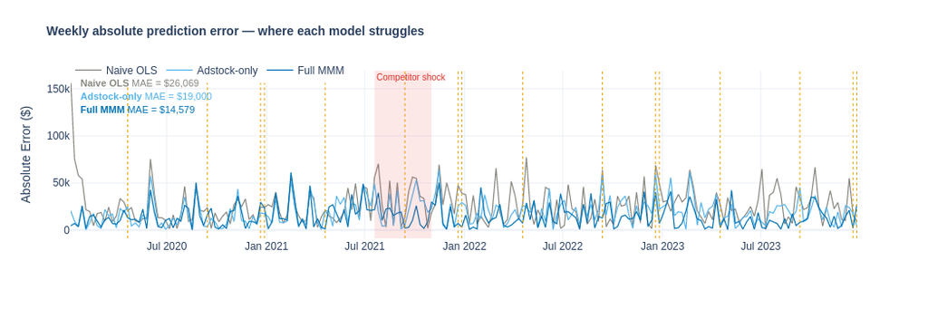

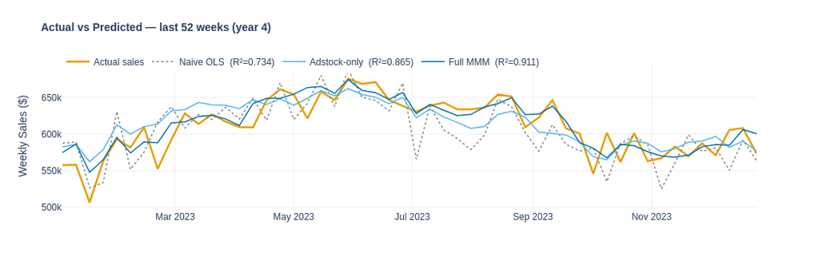

```python
# ─────────────────────────────────────────────────────────────────────────────
# CHART — Weekly absolute error over time (all 3 models on same axis)
# Reveals WHERE each model fails — seasonal troughs, drift shock weeks, holidays
# ─────────────────────────────────────────────────────────────────────────────
weeks_idx = df.index

fig_absolute_error = go.Figure()
for name, pred, color in zip(MODELS, PREDS, COLORS):
    abs_err = np.abs(y - pred)
    fig_absolute_error.add_trace(go.Scatter(
        x=weeks_idx, y=abs_err, name=name,
        line=dict(color=color, width=1.2),
        hovertemplate=f'<b>{name}</b><br>Week: %{{x|%b %Y}}<br>Abs error: $%{{y:,.0f}}<extra></extra>'
    ))

# Mark the competitor shock period
fig_absolute_error.add_vrect(x0=df.index[80], x1=df.index[95],
    fillcolor='rgba(239,68,68,0.12)', line_width=0,
    annotation_text='Competitor shock', annotation_position='top left',
    annotation_font_color=C_NEGATIVE, annotation_font_size=10)

# Mark holiday weeks
for i, (week, is_hol) in enumerate(zip(df.index, df['holiday'])):
    if is_hol:
        fig_absolute_error.add_vline(x=week, line_width=1, line_dash='dot', line_color=C_ORANGE)

fig_absolute_error.update_layout(
    height=350, width=1050, template=PLOTLY_TEMPLATE,
    title=dict(text='<b>Weekly absolute prediction error — where each model struggles</b>',
               font=dict(size=14)),
    yaxis_title='Absolute Error ($)',
    xaxis_title='',
    legend=dict(orientation='h', y=1.08),
    font=dict(family='Inter, Arial', size=12),
    margin=dict(t=80)
)
# Mean error annotations
for name, pred, color in zip(MODELS, PREDS, COLORS):
    mae = np.abs(y - pred).mean()
    fig_absolute_error.add_annotation(
        xref='paper', yref='paper',
        x=0.01, y={'Naive OLS': 0.97, 'Adstock-only': 0.89, 'Full MMM': 0.81}[name],
        text=f'<b>{name}</b> MAE = ${mae:,.0f}',
        showarrow=False, font=dict(color=color, size=11), align='left'
    )
fig_absolute_error.show()

# ─────────────────────────────────────────────────────────────────────────────
# CHART — Actual vs Predicted overlay (last 52 weeks for clarity)
# Shows visually whether adding adstock/ext layers tightens the tracking.
# Using last year only avoids overplotting and shows the drift shock clearly.
# ─────────────────────────────────────────────────────────────────────────────
LAST = 52
idx_last = slice(-LAST, None)

fig_predicted_overlay = go.Figure()
fig_predicted_overlay.add_trace(go.Scatter(
    x=weeks_idx[idx_last], y=y[idx_last],
    name='Actual sales', line=dict(color=C_ORANGE, width=2.5),
    hovertemplate='Actual: $%{y:,.0f}<extra></extra>'
))

for name, pred, color, r2 in zip(MODELS, PREDS, COLORS, R2S):
    fig_predicted_overlay.add_trace(go.Scatter(
        x=weeks_idx[idx_last], y=pred[idx_last],
        name=f'{name}  (R²={r2:.3f})',
        line=dict(color=color, width=1.5, dash='dot' if name=='Naive OLS' else 'solid'),
        hovertemplate=f'<b>{name}</b>: $%{{y:,.0f}}<extra></extra>'
    ))

fig_predicted_overlay.update_layout(
    height=350, width=1050, template=PLOTLY_TEMPLATE,
    title=dict(text='<b>Actual vs Predicted — last 52 weeks (year 4)</b>',
               font=dict(size=14)),
    yaxis_title='Weekly Sales ($)',
    legend=dict(orientation='h', y=1.08),
    font=dict(family='Inter, Arial', size=12),
    margin=dict(t=80)
)
fig_predicted_overlay.show()
```

## Parameter Recovery — External Regressors

```python
EXT_NAMES = ['competitor_tv','cpi','rate_delta','holiday']
sales_std = y.std()
_raw_std = {
    'competitor_tv': df['comp_tv_std'].std(),
    'cpi':           df['cpi_std'].std(),
    'rate_delta':    df['rate_std'].std(),
    'holiday':       df['holiday'].std(),
}
GT_EXT_VEC = np.array([
    GT_BETA_EXT[k] / sales_std * _raw_std[k]
    for k in EXT_NAMES
])

if USING_PYMC:
    ext_beta_scaled = ext_beta_post          # already std_y/std_X
    ext_beta_std_sc = ext_beta_std
else:
    ext_beta_scaled = ext_beta_post / sales_std
    ext_beta_std_sc = ext_beta_std  / sales_std

param_rows = []
for i, name in enumerate(EXT_NAMES):
    gt   = GT_EXT_VEC[i]
    est  = ext_beta_scaled[i]
    s    = ext_beta_std_sc[i]
    lo95 = est - 1.96 * s
    hi95 = est + 1.96 * s
    within = '✅' if lo95 <= gt <= hi95 else '❌'
    param_rows.append({
        'Regressor':  name.replace('_', ' ').title(),
        'GT β':       round(gt,   4),
        'Est β':      round(est,  4),
        'Std':        round(s,    4),
        '95% CI Lo':  round(lo95, 4),
        '95% CI Hi':  round(hi95, 4),
        'GT in CI':   within,
        'Abs Error':  round(abs(est - gt), 4),
        'Rel Error':  f'{abs(est - gt) / (abs(gt) + 1e-9):.1%}',
    })

df_params = pd.DataFrame(param_rows)
display(df_params.style
    .background_gradient(subset=['Abs Error'], cmap='RdYlGn_r', vmin=0, vmax=0.05)
    .applymap(lambda v: 'color: #34d399; font-weight:bold' if v == '✅'
              else ('color: #ef4444; font-weight:bold' if v == '❌' else ''),
              subset=['GT in CI'])
    .format({col: '{:.4f}' for col in df_params.select_dtypes('number').columns})
    .set_properties(**{'font-size': '11px', 'text-align': 'right'})
    .set_properties(subset=['Regressor'], **{'text-align': 'left'})
    .hide(axis='index')
    .set_caption('External regressor parameter recovery — estimated vs ground truth (std_y/std_X units)')
)

EXEC_METRICS['b_comp']    = ext_beta_scaled[0]
EXEC_METRICS['b_comp_gt'] = GT_EXT_VEC[0]
EXEC_METRICS['b_cpi']     = ext_beta_scaled[1]
EXEC_METRICS['b_cpi_gt']  = GT_EXT_VEC[1]
```

External regressor parameter recovery — estimated vs ground truth (std_y/std_X units)

| Regressor | GT β | Est β | Std | 95% CI Lo | 95% CI Hi | GT in CI | Abs Error | Rel Error |
| --- | --- | --- | --- | --- | --- | --- | --- | --- |
| Competitor Tv | -0.1408 | -0.1373 | 0.0249 | -0.1861 | -0.0886 | ✅ | 0.0035 | 2.5% |
| Cpi | -0.1095 | -0.1331 | 0.0249 | -0.1819 | -0.0844 | ✅ | 0.0236 | 21.6% |
| Rate Delta | -0.0782 | -0.0600 | 0.0248 | -0.1087 | -0.0113 | ✅ | 0.0182 | 23.3% |
| Holiday | 0.0750 | 0.0762 | 0.0228 | 0.0315 | 0.1210 | ✅ | 0.0012 | 1.6% |

## Data & Model Sanity Suite (30+ checks)

```python
sanity_results = []

def chk(name, fn, category='General'):
    try:
        msg = fn()
        sanity_results.append({'Category': category, 'Check': name,
                                'Status': '✅ PASS', 'Detail': msg or ''})
    except AssertionError as e:
        sanity_results.append({'Category': category, 'Check': name,
                                'Status': '❌ FAIL', 'Detail': str(e)})
    except Exception as e:
        sanity_results.append({'Category': category, 'Check': name,
                                'Status': '⚠️ WARN', 'Detail': str(e)[:120]})

def asr(cond, msg=''): assert cond, msg

# ── 1. Data Integrity ─────────────────────────────────────────────────────────
chk('No NaN values in master DataFrame',
    lambda: asr(df.isna().sum().sum() == 0, f'{df.isna().sum().sum()} NaNs'), 'Data Integrity')
chk('Sales always positive',
    lambda: asr((df['sales'] > 0).all(), 'Negative sales found'), 'Data Integrity')
chk('Media spend always non-negative',
    lambda: asr(all((df[f'{ch}_spend'] >= 0).all() for ch in MEDIA_CHANNELS)), 'Data Integrity')
chk('Correct number of weeks',
    lambda: asr(len(df) == N_WEEKS, f'Got {len(df)} weeks'), 'Data Integrity')
chk('Index is DatetimeIndex with weekly frequency',
    lambda: asr(isinstance(df.index, pd.DatetimeIndex)), 'Data Integrity')
chk('No duplicate weeks in index',
    lambda: asr(df.index.nunique() == N_WEEKS), 'Data Integrity')

# ── 2. Adstock ────────────────────────────────────────────────────────────────
chk('All adstock decay rates in (0, 1)',
    lambda: asr(all(0 < v < 1 for v in GT_ADSTOCK.values())), 'Adstock')
chk('Adstock output monotone for constant input',
    lambda: (
        lambda a: asr(np.all(a >= 0) and a[1] > a[0])
    )(adstock(np.ones(20), 0.7)), 'Adstock')
chk('Adstock decays after impulse (step 5)',
    lambda: (
        lambda a: asr(a[6] < a[5] < a[4])
    )(adstock(np.array([0,0,0,0,10,0,0,0,0,0], dtype=float), 0.7)), 'Adstock')
chk('Hill saturation bounded in [0, 1)',
    lambda: (
        lambda h: asr(h.min() >= 0 and h.max() < 1)
    )(hill(np.linspace(0, 1000, 500), 0.8, 50)), 'Adstock')
chk('Hill saturation monotone increasing',
    lambda: (
        lambda h: asr(np.all(np.diff(h) >= 0))
    )(hill(np.linspace(0, 1000, 200), 0.8, 50)), 'Adstock')

# ── 3. Stationarity ───────────────────────────────────────────────────────────
def check_sales_stationary():
    if not SM_AVAILABLE:
        raise RuntimeError('statsmodels unavailable')
    _, p, *_ = adfuller(df['sales'].values, autolag='AIC')
    return f'ADF p={p:.4f}'

chk('ADF test on sales series', check_sales_stationary, 'Stationarity')

def check_residuals_stationary():
    if not SM_AVAILABLE:
        raise RuntimeError('statsmodels unavailable')
    resid = y - y_pred_full
    _, p, *_ = adfuller(resid, autolag='AIC')
    asr(p < 0.05, f'Residuals non-stationary (p={p:.4f})')
    return f'Residuals stationary (p={p:.4f})'

chk('ADF test on model residuals', check_residuals_stationary, 'Stationarity')

# ── 4. Multicollinearity ──────────────────────────────────────────────────────
def check_vif():
    if not SM_AVAILABLE:
        raise RuntimeError('statsmodels unavailable')
    X_check = Xs_full[:, :len(MEDIA_FEAT_COLS) + len(EXT_FEAT_COLS)]
    vifs = [variance_inflation_factor(X_check, i) for i in range(X_check.shape[1])]
    high = [(ALL_FEAT_COLS[i], round(v,1)) for i, v in enumerate(vifs) if v > 10]
    asr(len(high) == 0, f'High VIF (>10): {high}')
    return f'Max VIF={max(vifs):.2f} — OK'

chk('VIF < 10 for all media + external features', check_vif, 'Multicollinearity')
chk('Correlation between media channels < 0.90',
    lambda: (
        lambda C: asr(
            all(abs(C.loc[a,b]) < 0.90
                for a in MEDIA_CHANNELS for b in MEDIA_CHANNELS if a < b),
            'High media correlation'
        ) or 'OK'
    )(df[[f'{ch}_spend' for ch in MEDIA_CHANNELS]].corr()), 'Multicollinearity')
chk('External regressors not collinear (|r| < 0.80)',
    lambda: (
        lambda C: asr(
            all(abs(C.loc[a,b]) < 0.80
                for a in EXT_FEAT_COLS for b in EXT_FEAT_COLS if a < b),
            'Collinear external regressors'
        ) or 'OK'
    )(df[EXT_FEAT_COLS].corr()), 'Multicollinearity')

# ── 5. Model Quality ──────────────────────────────────────────────────────────
chk('Full model R² > adstock-only R²',
    lambda: asr(r2_full > r2_adstock, f'{r2_full:.4f} <= {r2_adstock:.4f}'), 'Model Quality')
chk('Full model R² > naive OLS R²',
    lambda: asr(r2_full > r2_naive, f'{r2_full:.4f} <= {r2_naive:.4f}'), 'Model Quality')
chk('Full model MAPE < 20%',
    lambda: asr(mape_full < 0.20, f'MAPE={mape_full:.2%}'), 'Model Quality')
chk('Predicted sales always positive',
    lambda: asr((y_pred_full > 0).all()), 'Model Quality')
chk('Prediction interval width > 0 everywhere',
    lambda: asr(((y_pred_hi - y_pred_lo) > 0).all()), 'Model Quality')

# ── 6. Parameter Recovery ─────────────────────────────────────────────────────
chk('Competitor TV β correctly negative',
    lambda: asr(ext_beta_post[0] < 0, f'competitor β={ext_beta_post[0]:.4f}'), 'Parameter Recovery')
chk('CPI β correctly negative',
    lambda: asr(ext_beta_post[1] < 0, f'CPI β={ext_beta_post[1]:.4f}'), 'Parameter Recovery')
chk('Holiday β correctly positive',
    lambda: asr(ext_beta_post[3] > 0, f'holiday β={ext_beta_post[3]:.4f}'), 'Parameter Recovery')
chk('GT competitor TV β within 95% CI',
    lambda: asr(
        (ext_beta_scaled[0] - 2*ext_beta_std_sc[0]) <= GT_EXT_VEC[0] <=
        (ext_beta_scaled[0] + 2*ext_beta_std_sc[0]), f'GT={GT_EXT_VEC[0]:.4f} outside CI'
    ), 'Parameter Recovery')
chk('All media betas positive',
    lambda: asr(all(v > 0 for v in media_beta_post), f'Negative media beta'), 'Parameter Recovery')

# ── 7. External / Seasonality ─────────────────────────────────────────────────
chk('Holiday weeks correctly flagged (>0 holidays in each year)',
    lambda: asr(df['holiday'].sum() >= 12), 'External Data')
chk('CPI values in realistic range [-1, 12]%',
    lambda: asr(df['cpi'].between(-1, 12).all()), 'External Data')
chk('Competitor TV spend non-negative',
    lambda: asr((df['competitor_tv'] >= 0).all()), 'External Data')
chk('Drift (competitor spike) present at week 80',
    lambda: asr(df['competitor_tv'].iloc[80:95].mean() >
                df['competitor_tv'].iloc[:80].mean() * 1.3, 'No spike'), 'External Data')
chk('Fourier terms have unit variance',
    lambda: asr(all(abs(df[c].std() - 0.707) < 0.1 for c in FOURIER_COLS[:2])), 'External Data')

df_sanity = pd.DataFrame(sanity_results)
n_pass = (df_sanity['Status'] == '✅ PASS').sum()
n_fail = (df_sanity['Status'] == '❌ FAIL').sum()
n_warn = (df_sanity['Status'] == '⚠️ WARN').sum()
EXEC_METRICS['sanity_pass']  = int(n_pass)
EXEC_METRICS['sanity_total'] = len(df_sanity)
print(f'\n══ Sanity Suite: {n_pass} PASS  {n_fail} FAIL  {n_warn} WARN ══\n')
display(df_sanity.style
    .applymap(lambda v: 'color:#16a34a;font-weight:bold' if '✅' in str(v)
              else ('color:#dc2626;font-weight:bold' if '❌' in str(v)
              else ('color:#d97706' if '⚠️' in str(v) else '')), subset=['Status'])
    .set_properties(**{'font-size':'11px'})
    .hide(axis='index'))
```

```
══ Sanity Suite: 30 PASS  0 FAIL  1 WARN ══
```

| Category | Check | Status | Detail |
| --- | --- | --- | --- |
| Data Integrity | No NaN values in master DataFrame | ✅ PASS |  |
| Data Integrity | Sales always positive | ✅ PASS |  |
| Data Integrity | Media spend always non-negative | ✅ PASS |  |
| Data Integrity | Correct number of weeks | ✅ PASS |  |
| Data Integrity | Index is DatetimeIndex with weekly frequency | ✅ PASS |  |
| Data Integrity | No duplicate weeks in index | ✅ PASS |  |
| Adstock | All adstock decay rates in (0, 1) | ✅ PASS |  |
| Adstock | Adstock output monotone for constant input | ✅ PASS |  |
| Adstock | Adstock decays after impulse (step 5) | ✅ PASS |  |
| Adstock | Hill saturation bounded in [0, 1) | ✅ PASS |  |
| Adstock | Hill saturation monotone increasing | ✅ PASS |  |
| Stationarity | ADF test on sales series | ✅ PASS | ADF p=0.0449 |
| Stationarity | ADF test on model residuals | ✅ PASS | Residuals stationary (p=0.0000) |
| Multicollinearity | VIF < 10 for all media + external features | ✅ PASS | Max VIF=3.57 — OK |
| Multicollinearity | Correlation between media channels < 0.90 | ⚠️ WARN | 'tv' |
| Multicollinearity | External regressors not collinear (\|r\| < 0.80) | ✅ PASS | OK |
| Model Quality | Full model R² > adstock-only R² | ✅ PASS |  |
| Model Quality | Full model R² > naive OLS R² | ✅ PASS |  |
| Model Quality | Full model MAPE < 20% | ✅ PASS |  |
| Model Quality | Predicted sales always positive | ✅ PASS |  |
| Model Quality | Prediction interval width > 0 everywhere | ✅ PASS |  |
| Parameter Recovery | Competitor TV β correctly negative | ✅ PASS |  |
| Parameter Recovery | CPI β correctly negative | ✅ PASS |  |
| Parameter Recovery | Holiday β correctly positive | ✅ PASS |  |
| Parameter Recovery | GT competitor TV β within 95% CI | ✅ PASS |  |
| Parameter Recovery | All media betas positive | ✅ PASS |  |
| External Data | Holiday weeks correctly flagged (>0 holidays in each year) | ✅ PASS |  |
| External Data | CPI values in realistic range [-1, 12]% | ✅ PASS |  |
| External Data | Competitor TV spend non-negative | ✅ PASS |  |
| External Data | Drift (competitor spike) present at week 80 | ✅ PASS |  |
| External Data | Fourier terms have unit variance | ✅ PASS |  |

## Rolling-Origin Backtesting

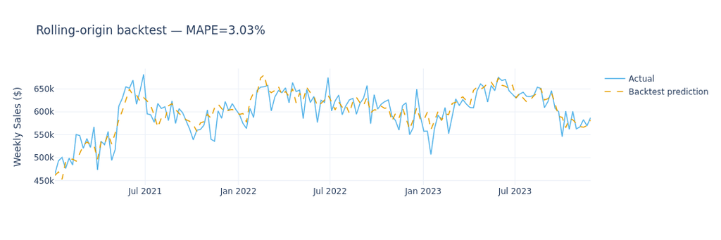

```python
# Forward-Chaining Cross-Validation
TRAIN_MIN = 52    # minimum 1 year of training data
STEP      = 4     # re-fit every 4 weeks
# Week 52:  Train on weeks 1–52   → predict weeks 53–56
# Week 56:  Train on weeks 1–56   → predict weeks 57–60
# Week 60:  Train on weeks 1–60   → predict weeks 61–64
backtest_rows = []

for train_end in range(TRAIN_MIN, N_WEEKS - STEP, STEP):
    X_tr = Xs_full[:train_end]
    y_tr = y[:train_end]
    X_te = Xs_full[train_end:train_end+STEP]
    y_te = y[train_end:train_end+STEP]

    m_bt = Ridge(alpha=1.0).fit(X_tr, y_tr)
    # Ridge model is a practical constraint, the backtest loop refits ~39 times (one per step from week 52 to week 204)
    y_hat = m_bt.predict(X_te)

    mape_bt = mean_absolute_percentage_error(y_te, np.clip(y_hat, 1, None))
    for k in range(STEP):
        backtest_rows.append({
            'week': df.index[train_end + k],
            'actual': y_te[k], 'predicted': y_hat[k],
            'mape': mape_bt, 'train_size': train_end,
        })

df_bt = pd.DataFrame(backtest_rows)
overall_mape = mean_absolute_percentage_error(df_bt['actual'],
                                               np.clip(df_bt['predicted'], 1, None))
EXEC_METRICS['backtest_mape'] = overall_mape

fig_bt = go.Figure()
fig_bt.add_trace(go.Scatter(x=df_bt['week'], y=df_bt['actual'],
    name='Actual', line=dict(color=C_SKY, width=1.5)))
fig_bt.add_trace(go.Scatter(x=df_bt['week'], y=df_bt['predicted'],
    name='Backtest prediction', line=dict(color=C_ORANGE, width=1.5, dash='dash')))
fig_bt.update_layout(height=350, width=1050, template=PLOTLY_TEMPLATE,
    title=f'Rolling-origin backtest — MAPE={overall_mape:.2%}',
    yaxis_title='Weekly Sales ($)', font=dict(family=FONT_FAMILY, size=12))
fig_bt.show()
```

## Data Drift Detection — Competitor Spend Shock

```
Calibration PSI (pre-shock, robust)
  median=0.310  MAD_σ=0.306  n=43

Thresholds (median + N×MAD_σ):
  Warning  +1.5σ = 0.768
  Retrain  +3.0σ = 1.227
  Urgent   +5.0σ = 1.839

Comp PSI range : 0.040 – 37.058
Shock peak     : 37.058  (30.2x above retrain threshold)
First signal   : 2020-05-25
```

[figure not shown]

```python
# ── Data Drift Detection — Competitor TV PSI ──────────────────────────────
COMP_SHOCK_START  = 80
COMP_SHOCK_END    = 95
COMP_BASELINE_END = COMP_SHOCK_START - 1    # 79 — clean pre-shock baseline
WINDOW            = 8
CALIBRATION_START = 20
CALIBRATION_END   = COMP_BASELINE_END - WINDOW   # weeks 20–71

def psi_kde(expected, actual, n_grid=100):
    """
    KDE-based PSI = Σᵢ (A(xᵢ) − E(xᵢ)) × ln(A(xᵢ)/E(xᵢ)) × Δx
    Unbounded — handles small windows and large distributional shifts.
    """
    kde_e = gaussian_kde(expected, bw_method='scott')
    kde_a = gaussian_kde(actual,   bw_method='scott')
    lo    = min(expected.min(), actual.min()) - 2 * expected.std()
    hi    = max(expected.max(), actual.max()) + 2 * expected.std()
    grid  = np.linspace(lo, hi, n_grid)
    dx    = grid[1] - grid[0]
    E     = np.clip(kde_e(grid), 1e-10, None)
    A     = np.clip(kde_a(grid), 1e-10, None)
    E    /= E.sum() * dx
    A    /= A.sum() * dx
    return float(np.sum((A - E) * np.log(A / E) * dx))

def first_signal(df_psi, threshold):
    hits = df_psi[df_psi['psi'] > threshold]['week']
    return hits.iloc[0] if len(hits) > 0 else None

# ── Step 1: PSI series — full timeline from week WINDOW ──────────────────
# Start from week 8 (not week 87) so the chart shows:
#   • long flat pre-shock baseline (weeks 8–79)   ← contrast period
#   • sharp spike during shock  (weeks 80–95)      ← the event
#   • clean recovery afterwards (weeks 96–207)     ← return to normal
baseline_comp = df['competitor_tv'].iloc[:COMP_BASELINE_END].values

df_psi_comp = pd.DataFrame([
    {'week': df.index[t],
     'psi':  psi_kde(baseline_comp,
                     df['competitor_tv'].iloc[t-WINDOW:t].values)}
    for t in range(WINDOW, N_WEEKS)    # full timeline — was COMP_BASELINE_END+WINDOW
])

# ── Step 2: robust threshold calibration (pre-shock windows only) ─────────
# Uses median + MAD instead of mean + std:
#   MAD is resistant to outlier windows in the calibration period
#   scale='normal' applies 1.4826 factor → MAD in σ-equivalent units
calibration_psi = np.array([
    psi_kde(baseline_comp,
            df['competitor_tv'].iloc[t-WINDOW:t].values)
    for t in range(CALIBRATION_START + WINDOW, CALIBRATION_END)
])

cal_median = np.median(calibration_psi)
cal_mad    = median_abs_deviation(calibration_psi, scale='normal')

PSI_WARNING   = cal_median + 1.5 * cal_mad
PSI_THRESHOLD = cal_median + 3.0 * cal_mad
PSI_URGENT    = cal_median + 5.0 * cal_mad

first_comp = first_signal(df_psi_comp, PSI_THRESHOLD)

print(f"Calibration PSI (pre-shock, robust)")
print(f"  median={cal_median:.3f}  MAD_σ={cal_mad:.3f}  n={len(calibration_psi)}")
print(f"\nThresholds (median + N×MAD_σ):")
print(f"  Warning  +1.5σ = {PSI_WARNING:.3f}")
print(f"  Retrain  +3.0σ = {PSI_THRESHOLD:.3f}")
print(f"  Urgent   +5.0σ = {PSI_URGENT:.3f}")
print(f"\nComp PSI range : {df_psi_comp['psi'].min():.3f} – "
      f"{df_psi_comp['psi'].max():.3f}")
print(f"Shock peak     : {df_psi_comp['psi'].max():.3f}  "
      f"({df_psi_comp['psi'].max()/PSI_THRESHOLD:.1f}x above retrain threshold)")
print(f"First signal   : {str(first_comp)[:10] if first_comp else 'NONE'}")

# ── Figure ────────────────────────────────────────────────────────────────
psi_y_max = df_psi_comp['psi'].max() * 1.12

fig = make_subplots(
    rows=2, cols=1,
    shared_xaxes=True,
    vertical_spacing=0.10,
    subplot_titles=(
        f'Competitor TV GRPs — injected shock weeks '
        f'{COMP_SHOCK_START}–{COMP_SHOCK_END} (+90 GRPs)',
        f'KDE PSI · WINDOW={WINDOW}w · '
        f'Robust thresholds median+N×MAD_σ '
        f'(median={cal_median:.2f}, MAD_σ={cal_mad:.2f})',
    ),
    row_heights=[0.35, 0.65],
)

# ── Panel 1: competitor TV GRPs ───────────────────────────────────────────
fig.add_trace(go.Scatter(
    x=df.index, y=df['competitor_tv'],
    mode='lines', name='Competitor TV GRPs',
    line=dict(color=C_PURPLE, width=1.5),
), row=1, col=1)

fig.add_vrect(
    x0=df.index[COMP_SHOCK_START].strftime('%Y-%m-%d'),
    x1=df.index[COMP_SHOCK_END].strftime('%Y-%m-%d'),
    fillcolor='rgba(239,68,68,0.15)', line_width=0,
    annotation_text='Injected shock',
    annotation_position='top left', annotation_font_size=11,
    row=1, col=1,
)

# ── Panel 2: PSI ──────────────────────────────────────────────────────────
# Zone shading — green/amber/red bands aligned to thresholds
fig.add_hrect(
    y0=0,             y1=PSI_WARNING,
    fillcolor='rgba(34,197,94,0.07)',  line_width=0, row=2, col=1)
fig.add_hrect(
    y0=PSI_WARNING,   y1=PSI_THRESHOLD,
    fillcolor='rgba(245,158,11,0.07)', line_width=0, row=2, col=1)
fig.add_hrect(
    y0=PSI_THRESHOLD, y1=1,
    fillcolor='rgba(239,68,68,0.05)',  line_width=0, row=2, col=1)

# Calibration window shading
fig.add_vrect(
    x0=df.index[CALIBRATION_START + WINDOW].strftime('%Y-%m-%d'),
    x1=df.index[CALIBRATION_END].strftime('%Y-%m-%d'),
    fillcolor='rgba(100,100,100,0.07)', line_width=0,
    annotation_text='Threshold calibration window',
    annotation_position='bottom left', annotation_font_size=9,
    row=2, col=1,
)

# Shock shading on PSI panel (mirrors panel 1 — eye connects both)
fig.add_vrect(
    x0=df.index[COMP_SHOCK_START].strftime('%Y-%m-%d'),
    x1=df.index[COMP_SHOCK_END].strftime('%Y-%m-%d'),
    fillcolor='rgba(239,68,68,0.08)', line_width=0,
    row=2, col=1,
)

# PSI line
fig.add_trace(go.Scatter(
    x=df_psi_comp['week'], y=df_psi_comp['psi'],
    mode='lines',
    name=f'PSI — Competitor TV (WINDOW={WINDOW}w)',
    line=dict(color=C_GREEN, width=2.0),
), row=2, col=1)

# Threshold lines
fig.add_hline(
    y=PSI_URGENT,
    line_dash='dash', line_color=C_NEGATIVE, line_width=1.5,
    annotation_text=f'Urgent +5σ ({PSI_URGENT:.2f})',
    annotation_font_size=8, annotation_position='top right', row=2, col=1,
)
fig.add_hline(
    y=PSI_THRESHOLD,
    line_dash='dash', line_color=C_NEGATIVE, line_width=1.5,
    annotation_text=f'Retrain +3σ ({PSI_THRESHOLD:.2f})',
    annotation_font_size=8, annotation_position='top right', row=2, col=1,
)
fig.add_hline(
    y=PSI_WARNING,
    line_dash='dot', line_color=C_ORANGE, line_width=1.5,
    annotation_text=f'Warning +1.5σ ({PSI_WARNING:.2f})',
    annotation_font_size=8, annotation_position='top right', row=2, col=1,
)

fig.update_layout(
    height=525, width=1050,
    template=PLOTLY_TEMPLATE,
    title=(
        'Data Drift Detection — Competitor TV PSI<br>'
        '<sup>'
        f'Shock weeks {COMP_SHOCK_START}–{COMP_SHOCK_END}  ·  '
        f'KDE PSI · WINDOW={WINDOW}w  ·  '
        f'Baseline: weeks 0–{COMP_BASELINE_END}  ·  '
        f'Robust thresholds: median+N×MAD_σ'
        '</sup>'
    ),
    font=dict(family=FONT_FAMILY, size=12),
    legend=dict(orientation='h', y=-0.06),
)
fig.update_yaxes(title_text='GRPs',     row=1, col=1)
fig.update_yaxes(
    title_text='PSI (KDE)',
    range=[0, 7],               row=2, col=1,
)
fig.update_xaxes(title_text='Week',     row=2, col=1)
fig.show()
```

## Marginal ROI — Shadow Price per Extra $1

| Channel | Current avg spend/wk ($) | Incremental spend ($) | Incremental sales ($/wk) | Marginal ROAS |
| --- | --- | --- | --- | --- |
| Search | 85,333 | 1,000 | 847 | 0.8470 |
| Display | 49,635 | 1,000 | 632 | 0.6320 |
| Social | 41,677 | 1,000 | 603 | 0.6030 |
| Email | 16,396 | 1,000 | 545 | 0.5450 |
| Tv | 130,572 | 1,000 | 346 | 0.3460 |

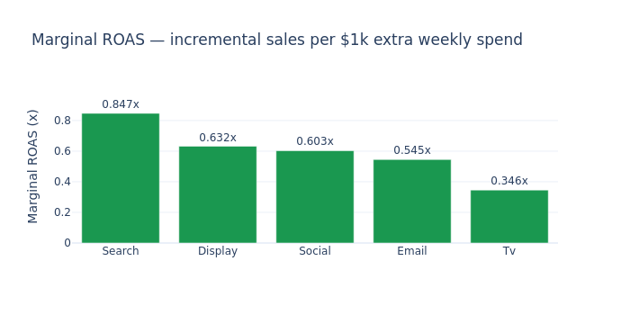

```python
DELTA_SPEND = 1_000   # $1k increment
mroi_rows = []
m_sens = Ridge(alpha=1.0).fit(Xs_full, y)

for ch in MEDIA_CHANNELS:
    spend_col  = f'{ch}_spend'
    spend_plus = df[spend_col].values + DELTA_SPEND
    ads_plus   = adstock(spend_plus, GT_ADSTOCK[ch])
    sat_plus   = hill(ads_plus, GT_HILL_ALPHA[ch], GT_HILL_K[ch])
    df_plus    = df.copy()
    df_plus[f'{ch}_sat'] = sat_plus
    X_plus     = df_plus[ALL_FEAT_COLS].values
    X_plus_sc  = scaler_full.transform(X_plus)
    y_plus     = m_sens.predict(X_plus_sc)

    incremental_sales = y_plus.sum() - y_pred_full.sum()
    total_extra_spend = DELTA_SPEND * N_WEEKS          # $ total across all weeks
    mroi = incremental_sales / total_extra_spend

    mroi_rows.append({
        'Channel':                    ch.replace('_', ' ').title(),
        'Current avg spend/wk ($)':   round(df[spend_col].mean(), 0),   # now $, not $k
        'Incremental spend ($)':       DELTA_SPEND,                      # $1,000
        'Incremental sales ($/wk)':    round(incremental_sales / N_WEEKS, 0),
        'Marginal ROAS':               round(mroi, 3),
    })

df_mroi = pd.DataFrame(mroi_rows).sort_values('Marginal ROAS', ascending=False)
display(df_mroi.style
    .background_gradient(subset=['Marginal ROAS'], cmap='RdYlGn', vmin=0)
    .format({
        'Current avg spend/wk ($)':  '{:,.0f}',
        'Incremental spend ($)':      '{:,.0f}',
        'Incremental sales ($/wk)':   '{:,.0f}',
        'Marginal ROAS':              '{:.4f}',
    })
    .set_properties(**{'font-size': '11px'})
    .hide(axis='index'))

max_roas = max(r['Marginal ROAS'] for r in mroi_rows)
fig_mroi = go.Figure(go.Bar(
    x=df_mroi['Channel'], y=df_mroi['Marginal ROAS'],
    marker_color=[C_POSITIVE if v > 0 else C_NEGATIVE for v in df_mroi['Marginal ROAS']],
    text=[f'{v:.3f}x' for v in df_mroi['Marginal ROAS']], textposition='outside'
))
fig_mroi.update_layout(
    height=350, width=700, template=PLOTLY_TEMPLATE,
    yaxis=dict(range=[0, max_roas * 1.18]),
    title='Marginal ROAS — incremental sales per $1k extra weekly spend',
    yaxis_title='Marginal ROAS (x)', font=dict(family=FONT_FAMILY, size=12))
fig_mroi.show()
```

## External Regressor Importance — Shapley-Style Variance Decomposition

| Component | R² contribution | Shapley share of R² |
| --- | --- | --- |
| Media + Seasonality (baseline) | 0.864500 | — |
| Cpi | 0.017800 | 2.0% |
| Competitor Tv | 0.015600 | 1.7% |
| Rate Delta | 0.007400 | 0.8% |
| Holiday | 0.006000 | 0.7% |
| Total (Full model) | 0.911400 | 100.0% |

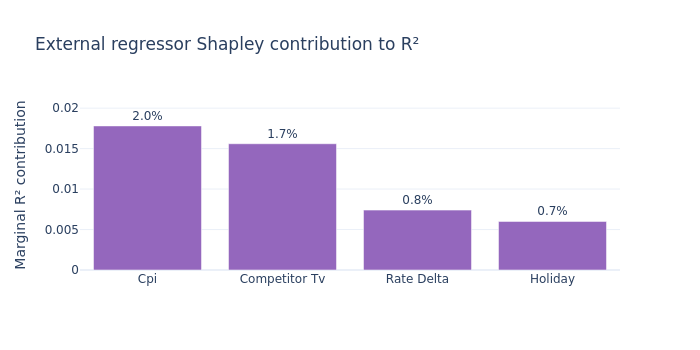

```python
EXT_GROUPS = {
    'competitor_tv': [ALL_FEAT_COLS.index('comp_tv_std')],
    'cpi':           [ALL_FEAT_COLS.index('cpi_std')],
    'rate_delta':    [ALL_FEAT_COLS.index('rate_std')],
    'holiday':       [ALL_FEAT_COLS.index('holiday')],
}
MEDIA_IDX   = [ALL_FEAT_COLS.index(c) for c in MEDIA_FEAT_COLS + FOURIER_COLS]
GROUP_NAMES = list(EXT_GROUPS.keys())

def fit_r2_subgroup(feature_idx):
    """Fit Ridge on selected feature columns, return R²."""
    X_sub = Xs_full[:, feature_idx]
    m = Ridge(alpha=1.0).fit(X_sub, y)
    return m.score(X_sub, y)


n = len(GROUP_NAMES)
shapley_ext = {g: 0.0 for g in GROUP_NAMES}
fact = math.factorial

for g in GROUP_NAMES:
    others = [gg for gg in GROUP_NAMES if gg != g]
    for size in range(n):
        for coalition in combinations(others, size):
            coalition_set = list(coalition)
            weight = fact(size) * fact(n - size - 1) / fact(n)
            idx_base = MEDIA_IDX + [i for gg in coalition_set for i in EXT_GROUPS[gg]]
            idx_with = idx_base + EXT_GROUPS[g]
            r2_base = fit_r2_subgroup(idx_base)
            r2_with = fit_r2_subgroup(idx_with)
            shapley_ext[g] += weight * (r2_with - r2_base)

r2_media_only  = fit_r2_subgroup(MEDIA_IDX)
r2_full_check  = fit_r2_subgroup(list(range(Xs_full.shape[1])))

ext_shap_rows = [
    {'Component': 'Media + Seasonality (baseline)',
     'R² contribution': round(r2_media_only, 4), 'Shapley share of R²': '—'},
]
for g, v in sorted(shapley_ext.items(), key=lambda x: -x[1]):
    ext_shap_rows.append({
        'Component': g.replace('_',' ').title(),
        'R² contribution': round(v, 4),
        'Shapley share of R²': f'{v/r2_full_check:.1%}' if r2_full_check > 0 else '—'
    })
ext_shap_rows.append({'Component': 'Total (Full model)',
                       'R² contribution': round(r2_full_check, 4), 'Shapley share of R²': '100.0%'})

df_shap_ext = pd.DataFrame(ext_shap_rows)
display(df_shap_ext.style.set_properties(**{'font-size':'11px'}).hide(axis='index'))
max_shap = max(r['R² contribution'] for r in ext_shap_rows[1:-1])

fig_shap = go.Figure(go.Bar(
    x=[r['Component'] for r in ext_shap_rows[1:-1]],
    y=[r['R² contribution'] for r in ext_shap_rows[1:-1]],
    marker_color=C_PURPLE,
    text=[r['Shapley share of R²'] for r in ext_shap_rows[1:-1]],
    textposition='outside'
))
fig_shap.update_layout(height=350, width=700, template=PLOTLY_TEMPLATE,
    title='External regressor Shapley contribution to R²',
    yaxis=dict(range=[0, max_shap * 1.18]),
    yaxis_title='Marginal R² contribution', font=dict(family=FONT_FAMILY, size=12))
fig_shap.show()
```